# What Is Data Science?

```
Science is organized knowledge.

    -Herbert Spencer
```

DJ Patil, the U.S. Government’s first Chief Data Scientist, defines data science as “the ability to extract knowledge and insights from large and complex data sets.” Data science is an umbrella term for a highly inter-disciplinary applied science that includes applications from the academic disciplines of computer science, mathematics, statistics, data mining, graphic design, data visualization, as well as substantive expertise in the specific domain of application. The figure below, with homage due to (Fry 2004) provides an illustration of how these disciplines interact in order to form a workflow for extracting knowledge from data.

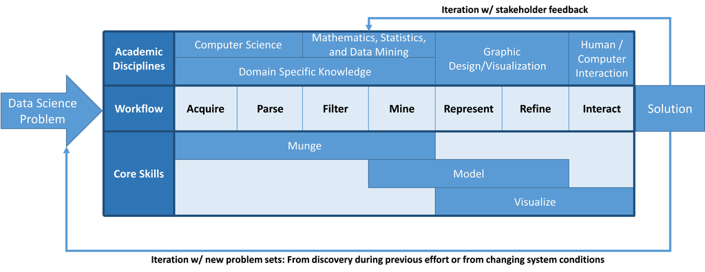

An illustration of how academic disciplines interact to form a data science workflow for understanding date, with homage due to Fry (2004).

The three core skills of a data scientist are the ability to “munge, model, and visually communicate data.” (Driscoll 2009) *Data munging* is a colloquial term used in computer science for extracting raw data, using programming and algorithms to convert it into an appropriate format, fusing various data sources together, and then storing the data in a format and location where it can be leveraged for further use (aquire/parse). Data scientists then apply models and algorithms from mathematics, statistics, machine learning, and/or data mining to extract key features and insights from the data (filter/mine). Finally, data scientists apply the principles of graphical design and data visualization to illustrate the key insights found in processing the data (represent, refine, interact). Note that interactivity (usually via a web browser) defines the difference between a visualization (interactive) and a graphic (static) representation of the data and/or findings.

**References**

Driscoll, Mike. “The Three Sexy Skills of Data Geeks.” 2009.

Fry, Benjamin. Computational Information Design. Boston: Dissertation, Massachusetts Institute of Technology, 2004.

Spencer, Herbert. *Education: Intellectual, Moral, and Physical.* Syracuse: C. W. Bardeen, 1894.